# Clase 09-Evaluación de supuestos análisis paramétricos

Curso Introducción al Análisis de datos con R para la acuicultura

Dr. José A. Gallardo y Dra. María Angélica Rueda.

Pontificia Universidad Católica de Valparaíso  
jose.gallardo@pucv.cl

17 July 2021

#### **Introducción**

Los principales supuestos de los análisis paramétricos son:

**Independencia**  
Cada observación de la muestra no debe estar relacionada con otra observación de la muestra.

**Homocedasticidad**  
En el caso de comparación de dos o más muestras éstas deben provenir de poblaciones con la misma varianza.

**Normalidad**  
Los datos de muestreo se obtienen de una población que tiene distribución normal.

**Regla de oro de los análisis paramétricos**  
Primero evalúe independencia, luego homogeneidad de varianzas y finalmente normalidad.

Esto porque la mayoría de las pruebas estadísticas paramétricas no toleran desvios de independencia, pero son bastante robustos a desviaciones de homogeneidad de varianzas o normalidad.

#### **Objetivos de aprendizaje**

Los objetivos de aprendizaje de esta guía son:

**1**. - Implementar métodos gráficos y análisis de residuos para evaluar supuestos de los análisis paramétricos.

**2**. - Implementar pruebas de hipótesis para evaluar supuestos de los análisis paramétricos.

**3**. - Elaborar un reporte dinámico en formato pdf con **[Rmarkdown](https://rmarkdown.rstudio.com/)**.

#### Librerías

| **Librería** | **Función** |
| --- | --- |
| **car** | Librería de acompañamiento al libro de J. Fox and S. Weisberg, An R Companion to Applied Regression, Third Edition, Sage, 2019. |
| **lmtest** | Librería que permite realizar análisis de diagnósticos de modelos lineales. |

#### **Comandos**

A continuación, se presentan algunos comandos que deberá usar para resolver los ejercicios de esta guía.

**1.-** Genera una gráfica de cuantiles teóricos de la distribución normal con relación a los cuantiles observados de los datos **qqnorm()**

**2.-** Genera una línea de regresión Y-X de cuantiles observados de los datos en función de los cuantiles teóricos con la distribución normal **qqline()**

**3.-** Función avanzada de gráficas qqplot de la librería car **qqPlot()**

**4.-** Ajusta modelos lineales con el formato de fórmula *(Variable Respuesta ~ Variable/s Explicativas)* **lm()**

**5.-** Realiza una prueba de normalidad de Shapiro-Wilk **shapiro.test()**

**6.-** Realiza una prueba de F para comparación de varianzas de dos muestras que provienen de poblaciones normales **vartest()**

**7.-** Prueba la hipótesis de homogeneidad de varianzas a través de 2 o más grupos, forma parte de la librería car **leveneTest()**

**8.-** Realiza una prueba de autocorrelación de Durbin-Watson **dwtest()**

### **Ejercicio 1.** Elaborar archivo Rmarkdown

Usando lo aprendido en la unidad 1 del curso elabore y configure un archivo o file con extensión **.Rmd** y configúrelo para exportar el resultado como un documento dinámico **pdf**.

Utilice el siguiente ejemplo para completar la información de metadatos: Título: Reporte Evaluación de supuestos análisis paramétricos, nombre del autor: Su nombre.

Luego guarde inmediatamente su *script* como **script_8_nombre_apellido.Rmd**. Al finalizar la actividad deberá exportar y almacenar este script en su carpeta drive de tareas.

### **Ejercicio 2.** Configuración del reporte

En el primer bloque de códigos o **chunk** configure los comandos de la siguiente manera *knitr::opts_chunk$set(echo = TRUE)* y cargue las librerías **readxl**, **car**, **lmtest**, **dplyr**, **knitr** y **ggplot2**.

```r
knitr::opts_chunk$set(echo = TRUE)

library(readxl)
library(car)
library(lmtest)
library(dplyr)
library(knitr)
library(ggplot2)
```

Ejecute cada uno de los siguientes ejercicios en uno o más bloques de códigos diferentes. Sea ordenado y documente su reporte adecuadamente.

### **Ejercicio 3.** Estudio de caso Tilapia

En el siguiente ejercicio se desea evaluar si los datos de crecimiento de 3 cepas de Tilapia cumplen con los supuestos del análisis de varianza.

**a).** Importe el set de datos **tilapia_cepas.csv** y realice un análisis exploratorio de datos. Transforme la variable Cepa en factor, use la función as.factor().

Incluya al menos un histograma y una gráfica de boxplot.

```r
tilapia_cepas<-read.csv("tilapia_cepas.csv", sep = ";")
tilapia_cepas$Cepa <- as.factor(tilapia_cepas$Cepa)
head(tilapia_cepas)
```

```
##   Muestra Peso   Cepa
## 1       1 4.17 Cepa 1
## 2       2 5.58 Cepa 1
## 3       3 5.18 Cepa 1
## 4       4 6.11 Cepa 1
## 5       5 4.50 Cepa 1
## 6       6 4.61 Cepa 1
```

```r
summary(tilapia_cepas)
```

```
##     Muestra           Peso           Cepa
##  Min.   : 1.00   Min.   :3.590   Cepa 1:10
##  1st Qu.: 8.25   1st Qu.:4.550   Cepa 3:10
##  Median :15.50   Median :5.155   Cepa2 :10
##  Mean   :15.50   Mean   :5.073
##  3rd Qu.:22.75   3rd Qu.:5.530
##  Max.   :30.00   Max.   :6.310
```

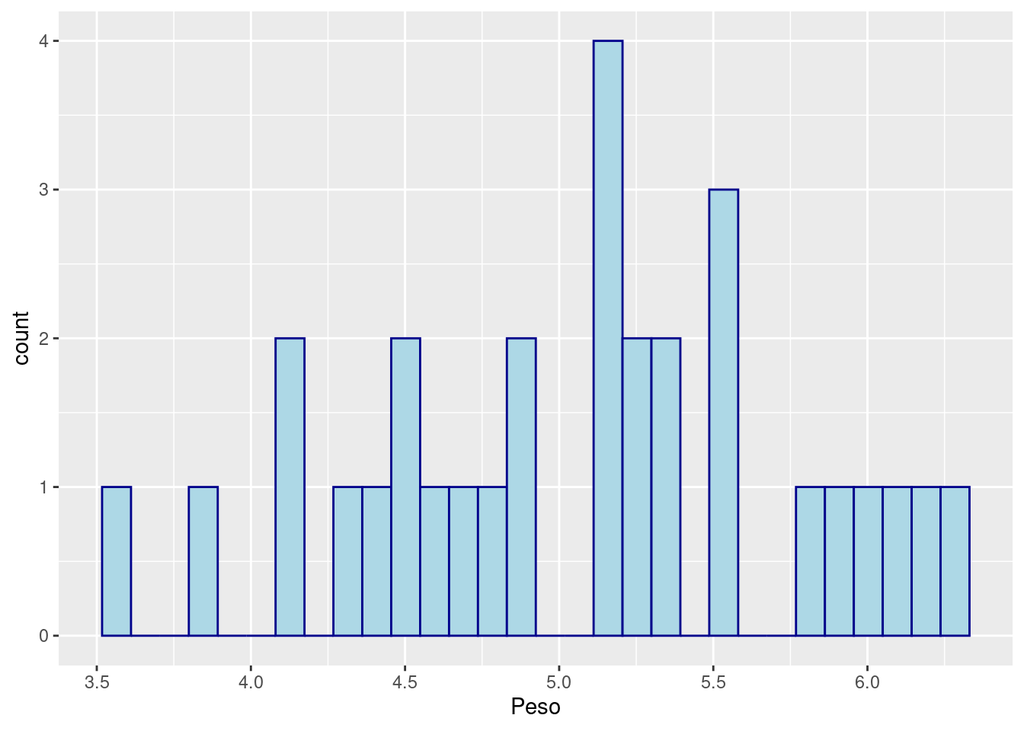

```r
p <-  ggplot(tilapia_cepas, aes(x=Peso))
p + geom_histogram(color="darkblue", fill="lightblue")
```

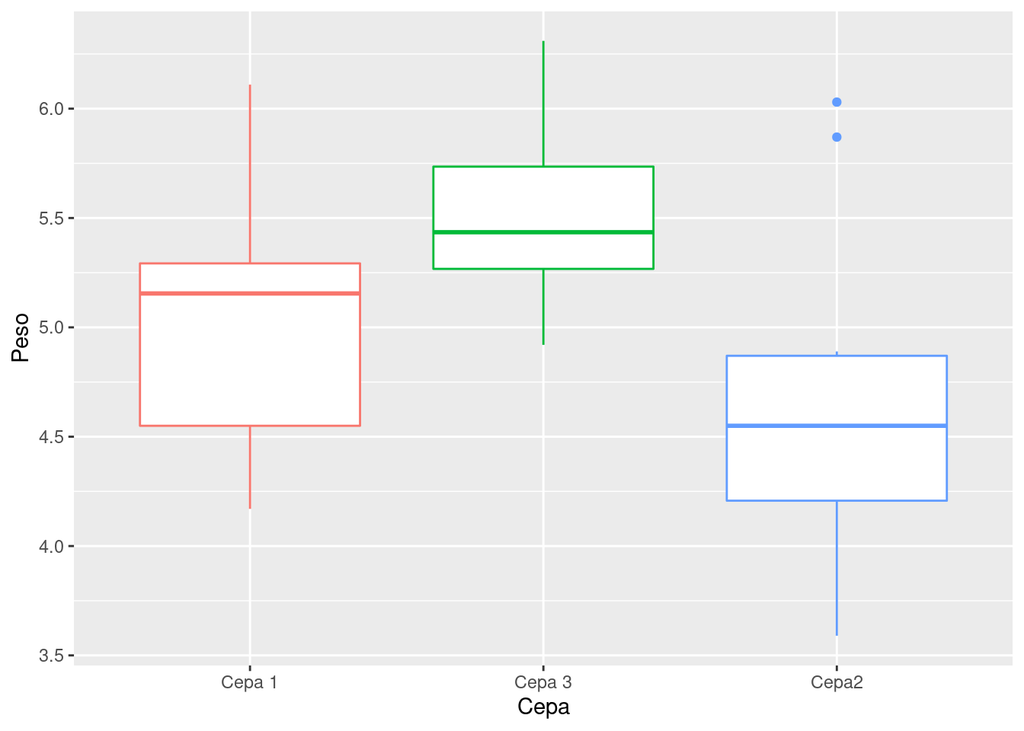

```r
q <-ggplot(tilapia_cepas, aes(x=Cepa, y=Peso, color=Cepa)) +
  geom_boxplot()+theme(legend.position="none")
q
```

**b).** Elabore un modelo lineal del análisis de varianza para este experimento.

Modelo lineal

```r
lm.aov <- lm(Peso ~ Cepa, data = tilapia_cepas)
aov(lm.aov)
```

```
## Call:
##    aov(formula = lm.aov)
##
## Terms:
##                     Cepa Residuals
## Sum of Squares   3.76634  10.49209
## Deg. of Freedom        2        27
##
## Residual standard error: 0.6233746
## Estimated effects may be unbalanced
```

**c).** Realice una evaluación de supuestos mediante métodos basados en análisis de residuales y pruebas de hipótesis.

Independencia

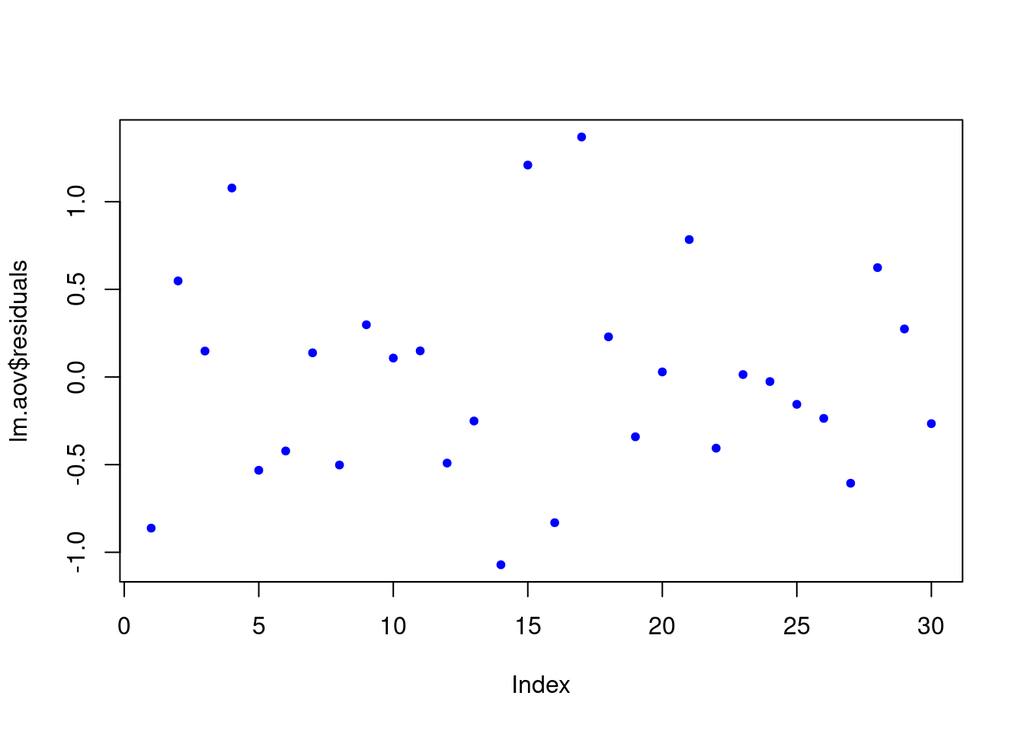

```r
plot(lm.aov$residuals, pch=20, col = "blue")
```

```r
dwtest(Peso ~ Cepa, data = tilapia_cepas,
       alternative = c("two.sided"),
       iterations = 15)
```

```
##
##  Durbin-Watson test
##
## data:  Peso ~ Cepa
## DW = 2.704, p-value = 0.09963
## alternative hypothesis: true autocorrelation is not 0
```

Homogeneidad de varianzas

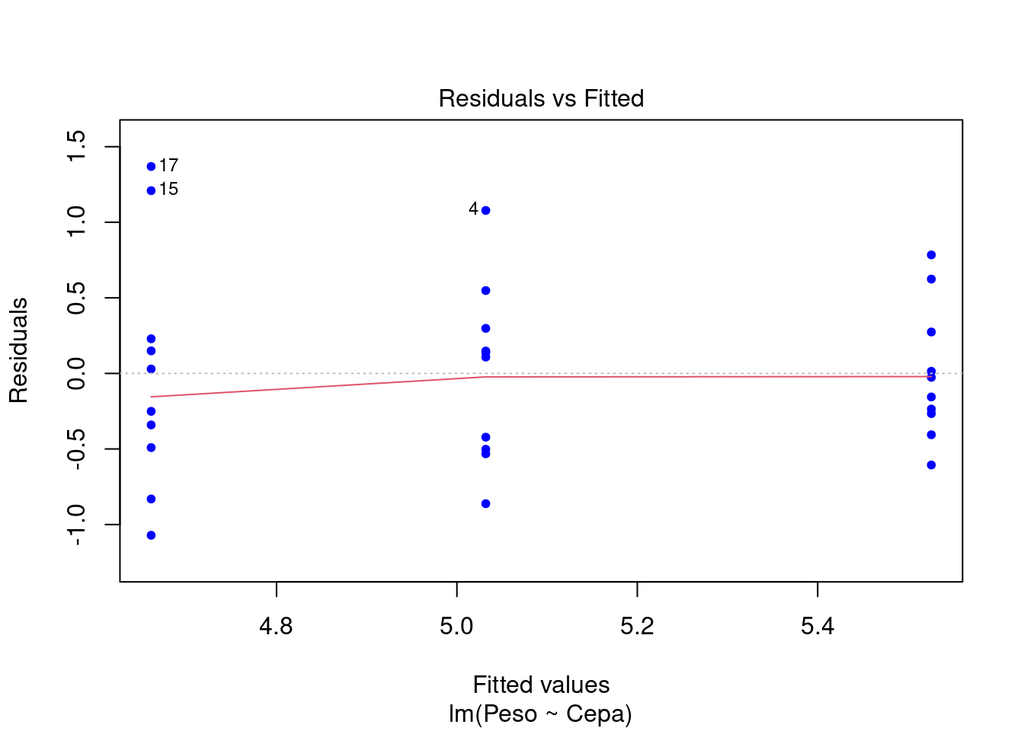

```r
plot(lm.aov, 1, pch=20, col = "blue")
```

```r
leveneTest(Peso ~ Cepa, data = tilapia_cepas,
           center = "median")
```

```
## Levene's Test for Homogeneity of Variance (center = "median")
##       Df F value Pr(>F)
## group  2  1.1192 0.3412
##       27
```

Normalidad

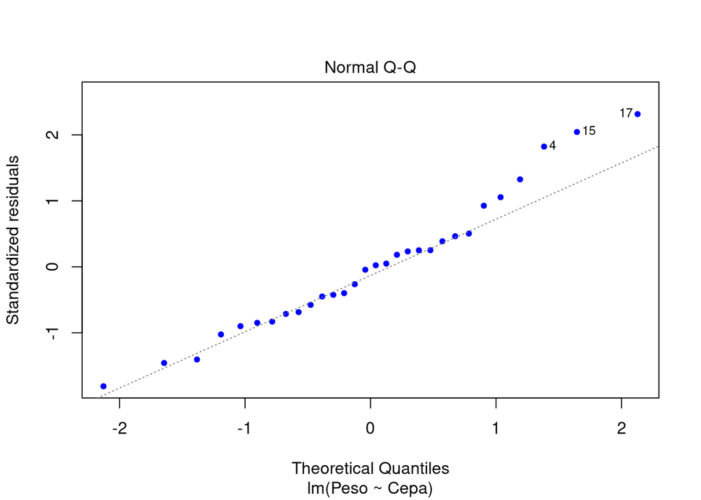

```r
plot(lm.aov, 2, pch=20, col = "blue")
```

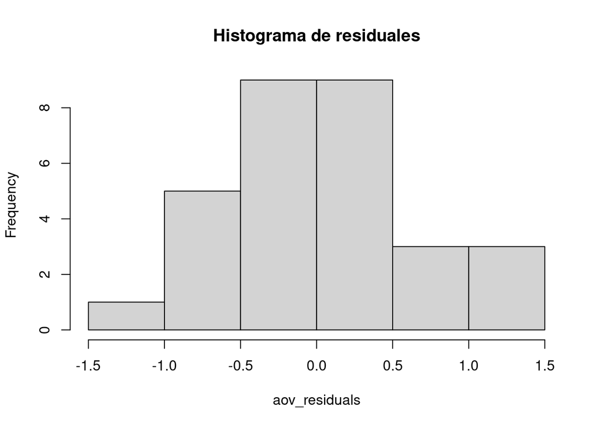

```r
aov_residuals <- residuals(object = lm.aov)
hist(x= aov_residuals, main = "Histograma de residuales")
```

```r
shapiro.test(x= aov_residuals)
```

```
##
##  Shapiro-Wilk normality test
##
## data:  aov_residuals
## W = 0.96607, p-value = 0.4379
```

**d).** Interprete sus resultados y concluya si es posible hacer o no un análisis de varianza para este experimento.

```r
#Se realizaron los gráficos y las pruebas para cada uno de los supuestos. Los resultados de las pruebas mostraron que se cumplían los tres supuestos (independencia, homogeneidad de varianzas y normalidad); ya que éstas pruebas presentaron p-valores superiores al nivel de significación del 5%. Debido al cumplimiento de los tres supuestos, se concluye que para este experimento es posible realizar el análisis de varianza.
```

### **Ejercicio 4.** Estudio de caso salmón

En el siguiente ejercicio se desea evaluar si los datos de crecimiento de diferentes grupos de peces (diploides y triploides) provenientes de diferentes familias de salmón y cultivados en dos estanques diferentes cumplen con los supuestos del análisis de varianza. Los datos fueron colectados por [Harvey y colaboradores, 2017](https://doi.org/10.1186/s12863-017-0502-x)

**a).** Importe el set de datos **Harvey_dat.xlsx** y realice un análisis exploratorio de datos.

Incluya al menos un histograma y una gráfica de boxplot.

```r
Harvey_dat <- read_excel("Harvey_dat.xlsx")
head(Harvey_dat)
```

```
## # A tibble: 6 x 5
##   Sample Family Ploidy  Weight Length
##   <chr>  <chr>  <chr>    <dbl>  <dbl>
## 1 M3     19     Diploid     49   15.7
## 2 M8     19     Diploid     46   15.1
## 3 M12    1      Diploid     54   16
## 4 M13    15     Diploid     31   13
## 5 M14    9      Diploid     46   14.9
## 6 M20    9      Diploid     37   14
```

```r
Harvey_dat$Family <- as.factor(Harvey_dat$Family)
Harvey_dat$Ploidy <- as.factor(Harvey_dat$Ploidy)
summary(Harvey_dat)
```

```
##     Sample          Family       Ploidy        Weight          Length
##  Length:251         1 :40   Diploid :232   Min.   : 4.00   Min.   : 6.90
##  Class :character   11:33   Triploid: 19   1st Qu.:32.00   1st Qu.:13.40
##  Mode  :character   15:42                  Median :37.00   Median :14.00
##                     17:31                  Mean   :35.88   Mean   :13.79
##                     19:41                  3rd Qu.:41.00   3rd Qu.:14.60
##                     5 :27                  Max.   :54.00   Max.   :16.00
##                     9 :37
```

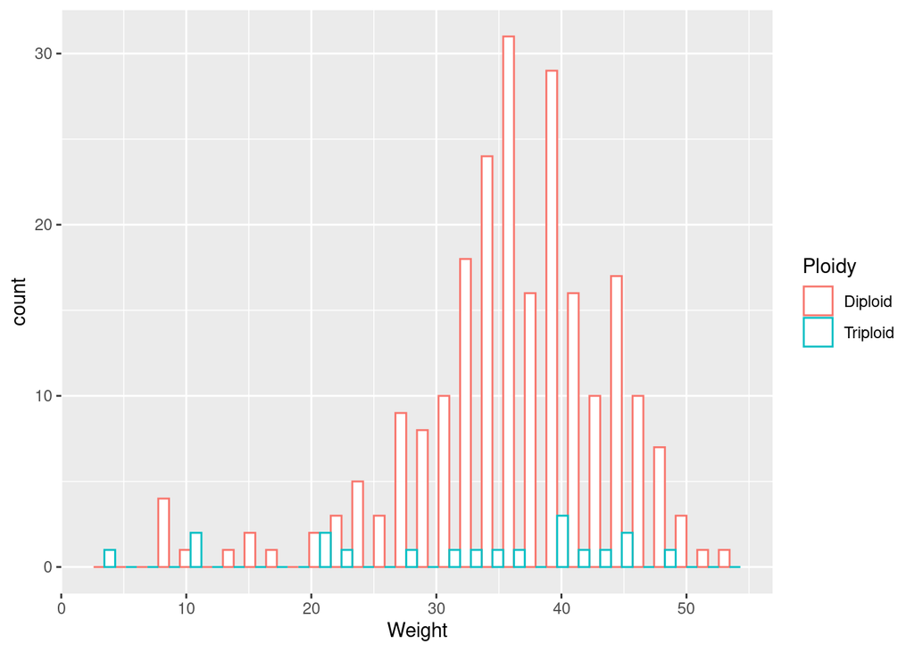

```r
Harvey_dat %>%
  ggplot(aes(x=Weight, color=Ploidy)) +
  geom_histogram(fill="white", position="dodge")+
  theme(legend.position="right")
```

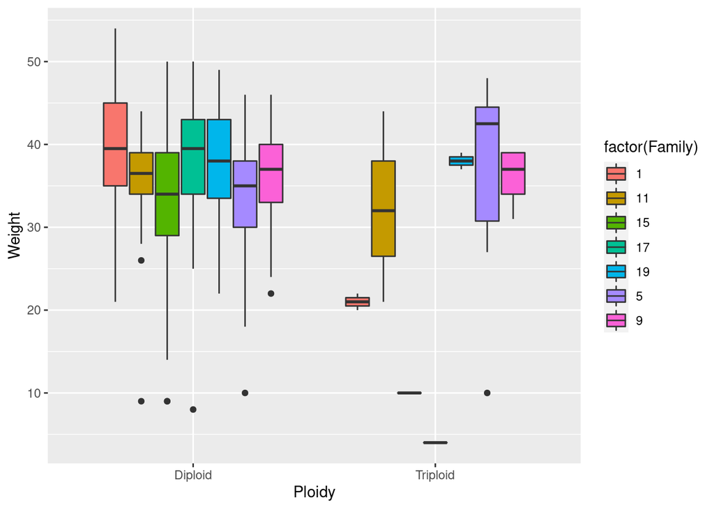

```r
Harvey_dat %>%
  ggplot(aes(x=Ploidy, y=Weight, fill=factor(Family))) +
  geom_boxplot()
```

**b).** Elabore un modelo lineal del análisis de varianza de dos vías con interacción para este experimento.

Modelo lineal

```r
lm.aov1 <- lm(Weight ~ Ploidy * Family, data = Harvey_dat)
aov(lm.aov1)
```

```
## Call:
##    aov(formula = lm.aov1)
##
## Terms:
##                    Ploidy    Family Ploidy:Family Residuals
## Sum of Squares    501.051  1149.734      1885.719 14729.145
## Deg. of Freedom         1         6             6       237
##
## Residual standard error: 7.883419
## Estimated effects may be unbalanced
```

**c).** Realice una evaluación de supuestos mediante métodos basados en análisis de residuales y pruebas de hipótesis.

Independencia

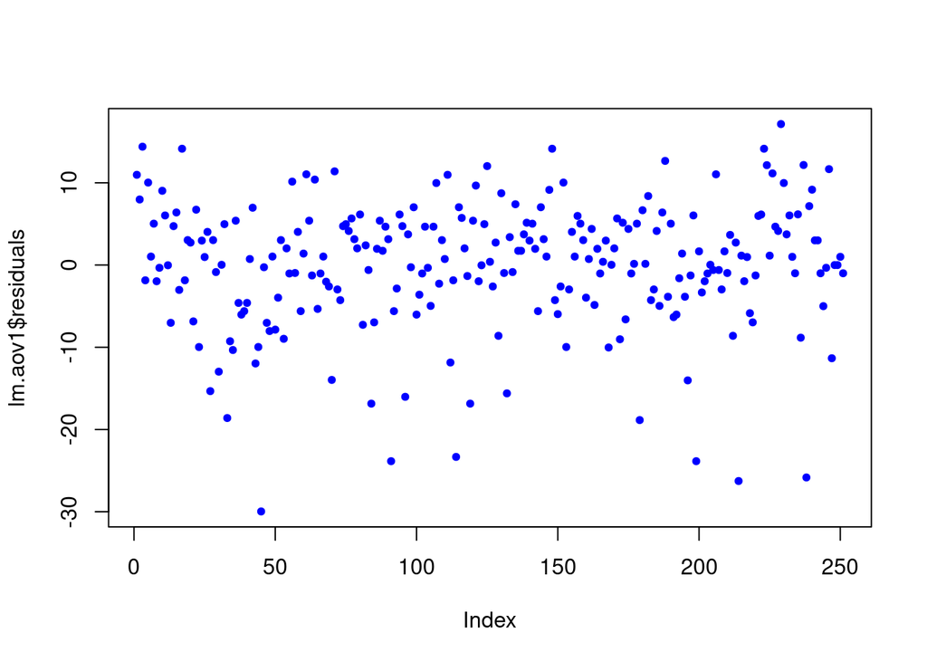

```r
plot(lm.aov1$residuals, pch=20, col = "blue")
```

```r
dwtest(Weight ~ Ploidy * Family, data = Harvey_dat,
       alternative = c("two.sided"),
       iterations = 15)
```

```
##
##  Durbin-Watson test
##
## data:  Weight ~ Ploidy * Family
## DW = 2.0781, p-value = 0.7102
## alternative hypothesis: true autocorrelation is not 0
```

Homogeneidad de varianzas

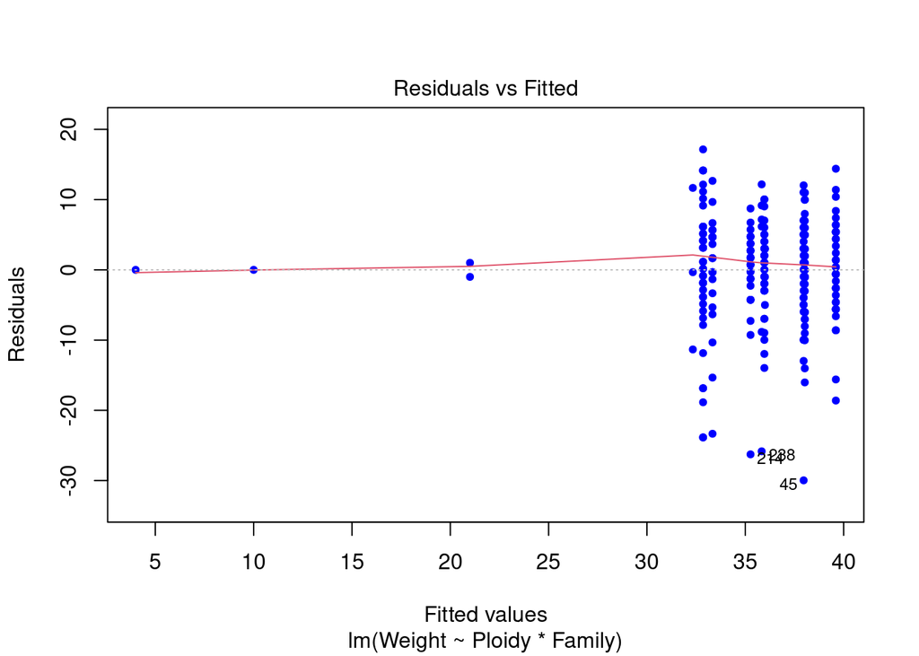

```r
plot(lm.aov1, 1, pch=20, col = "blue")
```

```r
leveneTest(Weight ~ Ploidy * Family, data = Harvey_dat,
           center = "median")
```

```
## Levene's Test for Homogeneity of Variance (center = "median")
##        Df F value Pr(>F)
## group  13  1.4728 0.1283
##       237
```

Normalidad

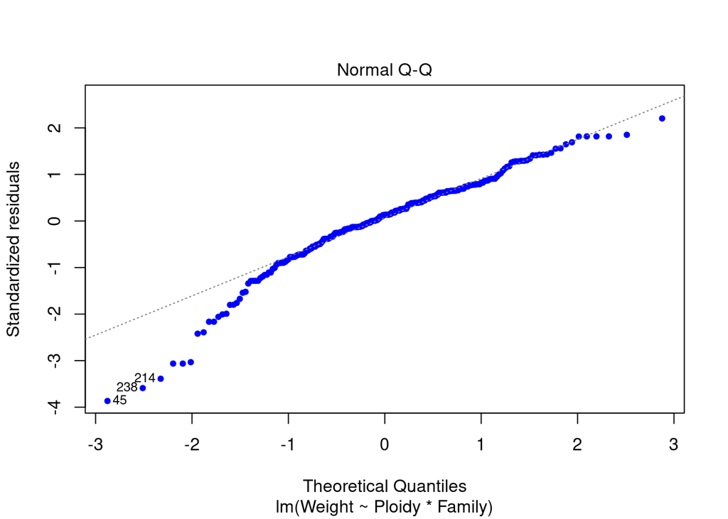

```r
plot(lm.aov1, 2, pch=20, col = "blue")
```

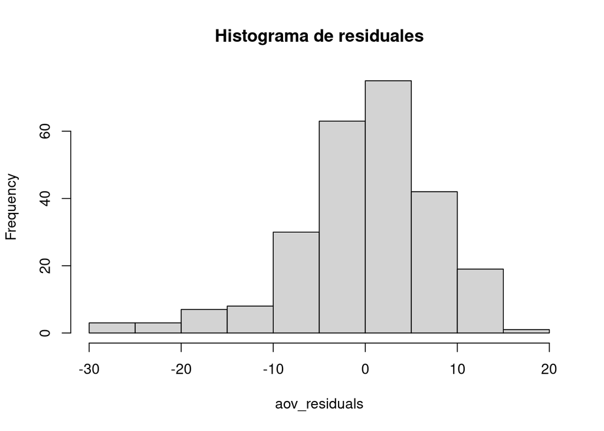

```r
aov_residuals <- residuals(object = lm.aov1)
hist(x= aov_residuals, main = "Histograma de residuales")
```

```r
shapiro.test(x= aov_residuals)
```

```
##
##  Shapiro-Wilk normality test
##
## data:  aov_residuals
## W = 0.94665, p-value = 6.123e-08
```

**d).** Interprete sus resultados y concluya si es posible hacer o no un análisis de varianza para este experimento.

```r
#Se realizaron los gráficos y las pruebas para cada uno de los supuestos. Los resultados de las pruebas mostraron que se cumplían solo dos supuestos (independencia y homogeneidad de varianzas); ya que éstas pruebas presentaron p-valores superiores al nivel de significación del 5%. Debido al incumplimiento del supuesto de normalidad, se concluye que para este experimento no es posible realizar el análisis de varianza.
```

### **Ejercicio 5.** Estudio de caso trucha

En el siguiente ejercicio se debe evaluar sí se cumplen los supuestos para realizar un análisis de correlación entre las variables peso del cuerpo (weight) y Peso de filete (fillet) obtenidos de una planta de proceso de truchas.

**a).** Importe el set de datos **trucha.xlsx** y realice un análisis exploratorio de datos.

```r
trucha <- read_excel("trucha.xlsx")
head(trucha)
```

```
## # A tibble: 6 x 3
##      id weight fillet
##   <dbl>  <dbl>  <dbl>
## 1     1  3403.  2040.
## 2     2  4600.  3137.
## 3     3  1350.   905.
## 4     4  2641.  1680.
## 5     5  3214.  2314.
## 6     6  5244.  3514.
```

```r
summary(trucha)
```

```
##        id             weight         fillet
##  Min.   :  1.00   Min.   :1053   Min.   : 113
##  1st Qu.: 25.75   1st Qu.:2786   1st Qu.:1806
##  Median : 50.50   Median :3469   Median :2297
##  Mean   : 50.50   Mean   :3559   Mean   :2326
##  3rd Qu.: 75.25   3rd Qu.:4117   3rd Qu.:2755
##  Max.   :100.00   Max.   :6377   Max.   :4543
```

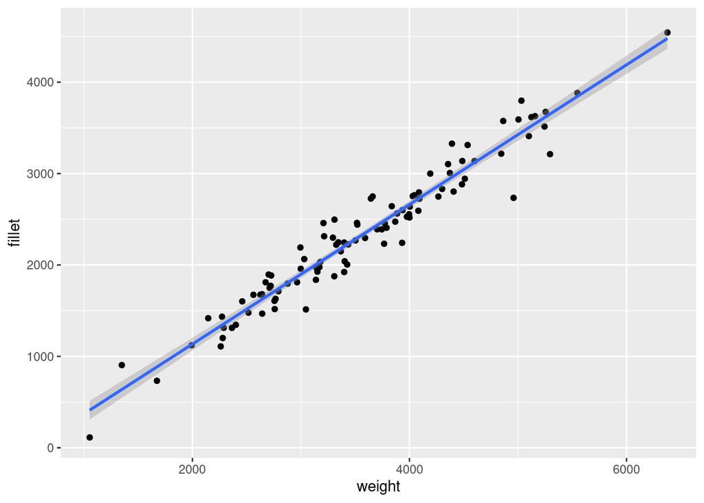

```r
ggplot(trucha, aes(x=weight, y=fillet)) + geom_point() + geom_smooth(method=lm)
```

**b).** Elabore un modelo lineal donde fillet está en función del weight.

Modelo lineal

```r
lm.aov2 <- lm(fillet ~ weight, data = trucha)
```

**c).** Realice una evaluación de supuestos mediante métodos gráficos y pruebas de hipótesis.

Independencia

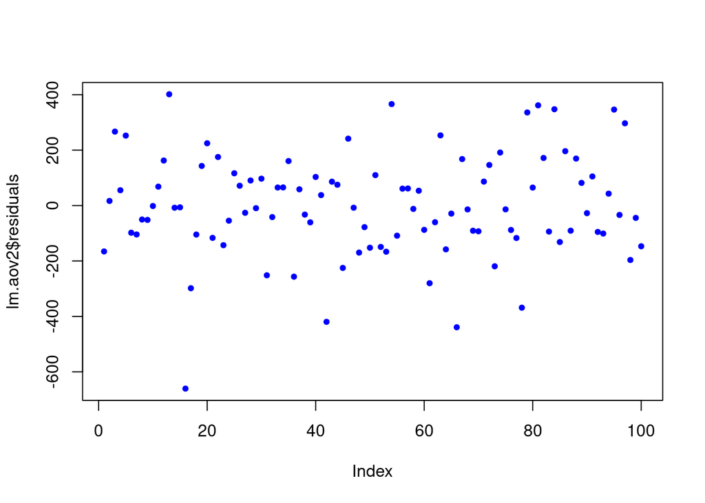

```r
plot(lm.aov2$residuals, pch=20, col = "blue")
```

```r
dwtest(fillet ~ weight, data = trucha,
       alternative = c("two.sided"),
       iterations = 15)
```

```
##
##  Durbin-Watson test
##
## data:  fillet ~ weight
## DW = 2.1569, p-value = 0.4241
## alternative hypothesis: true autocorrelation is not 0
```

Normalidad

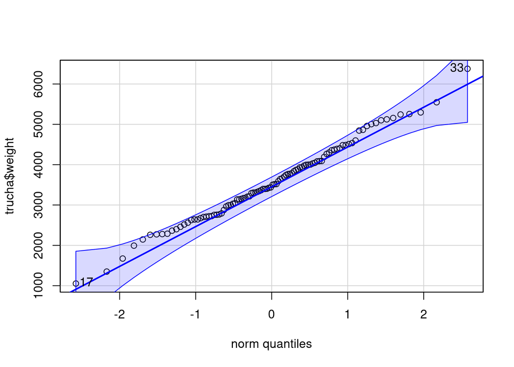

```
## [1] 33 17
```

```r
qqPlot(trucha$weight)
```

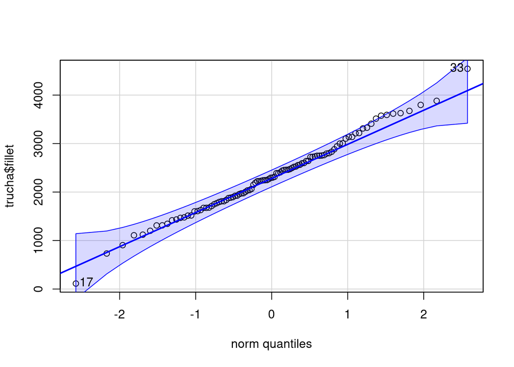

```
## [1] 33 17
```

```r
qqPlot(trucha$fillet)
```

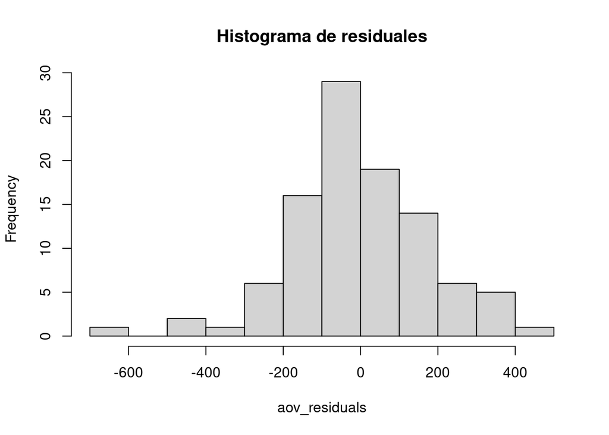

```r
aov_residuals <- residuals(object = lm.aov2)
hist(x= aov_residuals, main = "Histograma de residuales")
```

```r
shapiro.test(x= aov_residuals)
```

```
##
##  Shapiro-Wilk normality test
##
## data:  aov_residuals
## W = 0.978, p-value = 0.09268
```

**d).** ¿Qué otro supuesto tienen los análisis de correlación paramétricos además de independencia y normalidad? En este ejercicio considere el test de Breusch-Pagan como test de hipótesis para la homocedasticidad del análisis de correlación, use la función bptest().

```r
#El otro supuesto que tiene el análisis de correlación es el de homogeneidad de varianzas.
```

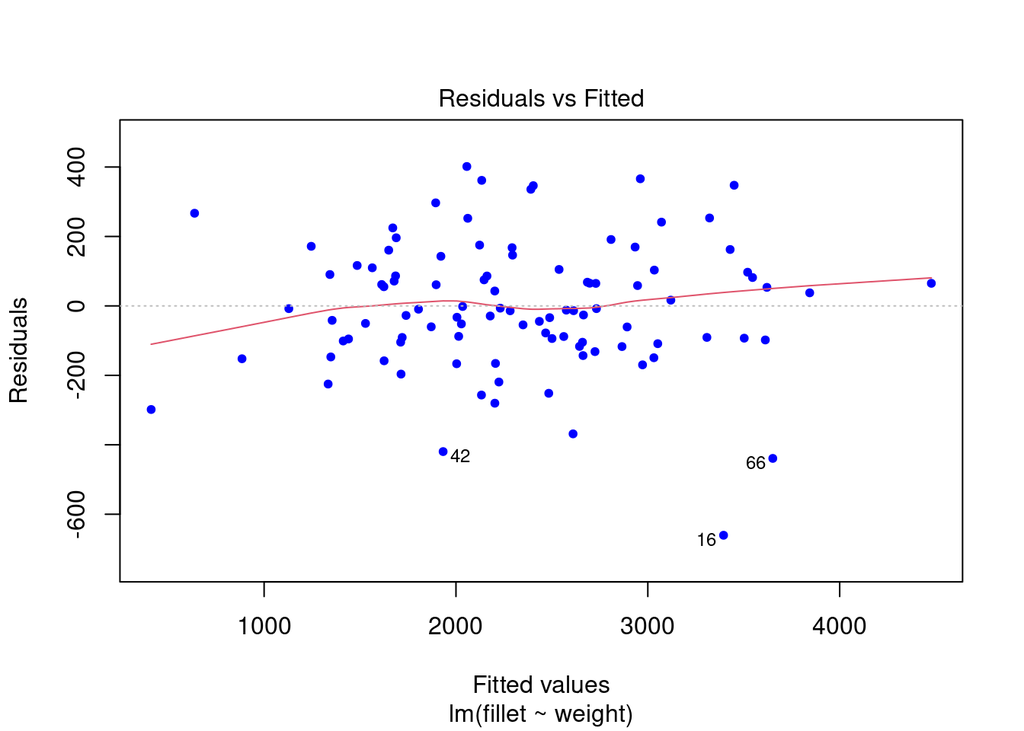

```r
plot(lm.aov2, 1, pch=20, col = "blue")
```

```r
# test de hipótesis para la homocedasticidad en correlación
bptest(lm.aov2)
```

```
##
##  studentized Breusch-Pagan test
##
## data:  lm.aov2
## BP = 1.1785, df = 1, p-value = 0.2777
```

**d).** Interprete sus resultados y concluya si es posible hacer o no un análisis de varianza para este experimento.

```r
#Se realizaron gráficos y las pruebas para cada uno de los supuestos. Los resultados de las pruebas mostraron que se cumplían los tres supuestos (independencia, homogeneidad de varianzas y normalidad); ya que éstas pruebas presentaron p-valores superiores al nivel de significación del 5%. Debido al cumplimiento de los tres supuestos, se concluye que para este experimento es posible realizar el análisis de varianza.
```